# Taylor Swift Sentiment Analysis

Tiffany Hsu

```r
# setting up tibble
text_tba <- tibble(album = taylorSwiftAlbums$album,
                    word = taylorSwiftAlbums$lyric)
```

## AFINN Analysis by Album

```r
afinn1 <- text_tba %>%
    group_by(album) %>%
    inner_join(get_sentiments("afinn")) %>%
    group_by(album) %>%
    summarise(sentiment = sum(score)) %>%
    mutate(method = "AFINN")

afinnplot1 =  afinn1 %>%
    ggplot(aes(as.factor(album), sentiment)) +
    geom_bar(stat='identity', position='dodge', fill = "red")
    geom_col(show.legend = FALSE)
```

```
## geom_col: width = NULL, na.rm = FALSE
## stat_identity: na.rm = FALSE
## position_stack
```

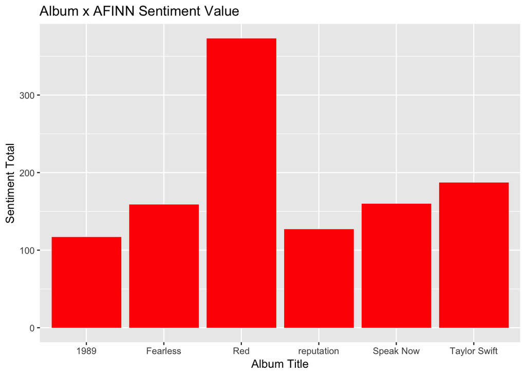

```r
afinnplot1 + ggtitle("Album x AFINN Sentiment Value") +
      xlab("Album Title") + ylab("Sentiment Total")
```

AFINN analysis pairs each word to a numeric value (from -5 to +5), on how positive each word is. These words are then totalled up to reveal the overall sentiment per album. From the barplot, it can be concluded that Taylor Swift’s album ‘Red’ had the most positive sentiment, meaning she used more positive words in her music.

## Bing Analysis by Album

```r
bing = text_tba %>%
      group_by(album) %>%
      inner_join(get_sentiments("bing")) %>% # pull out only sentiment words
      count(sentiment) %>% # count the # of positive & negative words
      spread(sentiment, n, fill = 0) %>% # made data wide rather than narrow
      mutate(sentiment = positive - negative)


bingplot =  bing %>%
    ggplot(aes(as.factor(album), sentiment)) +
    geom_bar(stat='identity', position='dodge', fill = "blue")
    geom_col(show.legend = FALSE)
```

```
## geom_col: width = NULL, na.rm = FALSE
## stat_identity: na.rm = FALSE
## position_stack
```

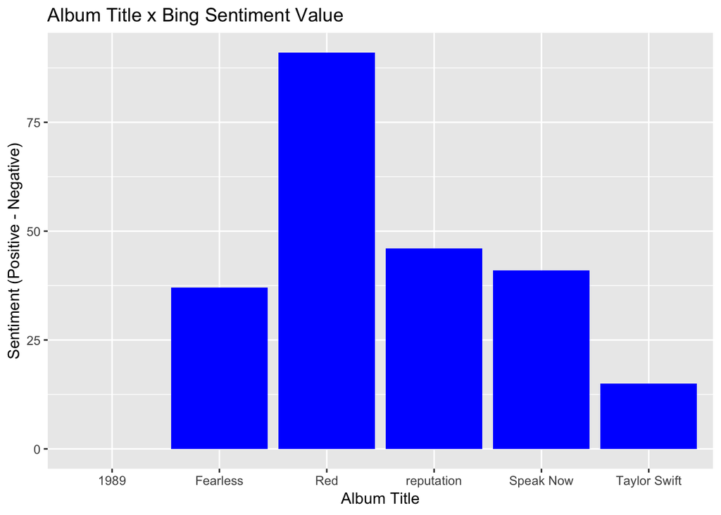

```r
bingplot + ggtitle("Album Title x Bing Sentiment Value") +
  xlab("Album Title") + ylab("Sentiment (Positive - Negative)")
```

## NRC Analysis by Album

```r
nrc = text_tba %>%
  group_by(album) %>%
  inner_join(get_sentiments("nrc")) %>%
  count(sentiment) %>%
  spread(sentiment, n, fill = 0)  # made data wide rather than narrow

transpose = as_tibble(cbind(nms = names(nrc), t(nrc)))
colnames(transpose) = transpose[1,]

chartJSRadar(transpose[2:11,])
```

[interactive chart not shown]

NRC analysis assigns each lyric to a different sentiment category: sadness, surprise, trust, anger, anticipation, disgust, fear, postive, or negative. The words in each category is then totalled. From the radar chart, it can be concluded that ‘Red’ and ‘Speak Now’ had the most positive words.

## Taking a Closer Look into ‘Red’

```r
# subsetting 'Red'
red = taylorSwift[taylorSwift$album == 'Red',]
List <- strsplit(as.character(red$lyric), " ")
redSongs = data.frame(track_title=rep(red$track_title, sapply(List, length)), lyric=unlist(List))
```

```r
red_tba <- tibble(track_title = redSongs$track_title,
                    word = redSongs$lyric)

afinnRed <- red_tba %>%
    group_by(track_title) %>%
    inner_join(get_sentiments("afinn")) %>%
    group_by(track_title) %>%
    summarise(sentiment = mean(score)) %>%
    mutate(method = "AFINN")

redplot =  afinnRed %>%
    ggplot(aes(as.factor(track_title), sentiment)) +
    geom_bar(stat='identity', position='dodge', fill = "red")
    geom_col(show.legend = FALSE)
```

```
## geom_col: width = NULL, na.rm = FALSE
## stat_identity: na.rm = FALSE
## position_stack
```

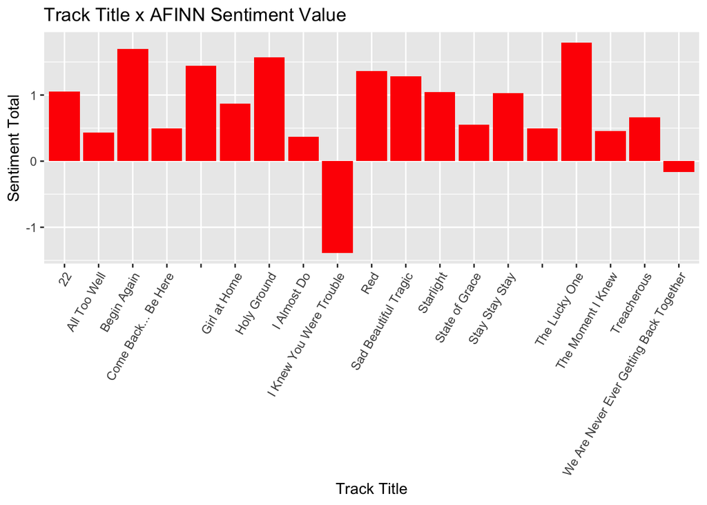

```r
redplot + ggtitle("Track Title x AFINN Sentiment Value") +
      xlab("Track Title") + ylab("Sentiment Total") +
    theme(axis.text.x = element_text(angle = 60, hjust = 1))
```